# Covid 19 - Bauru

Leandro

13/03/2022

Importando as bibliotecas necessárias.

```r
library(tidyverse)
library(plotly)
library(ggrepel)
library(PerformanceAnalytics)
library(reshape2)
library(readxl)
library("bbl")
library("ggQC")
library(rmarkdown)
```

Importando os dados.

```r
dataset_casosbauru_geral <- read_delim("../dados/covid_19_bauru_casos_geral.csv",delim = ";")
dataset_casosbauru_mortes <- read_delim("../dados/covid_19_bauru_mortes.csv",delim = ";")
```

Classificação das variáveis:

dataset_casosbauru_geral:

data_boletim: data de publicação do boletim epidemiológico. Formato dd/mm/aa. Variável continua. casos_novos: número de novas infecções declaradas. Variável contínua. confirmacoes_total: Número total de casos novos detectados de Covid-19 até a data. Variável contínua. total_mortes: Número total de óbitos de Covid-19 até a data. Variável contínua. mortes_suspeitas: Número total de óbitos ocorridos até a data suspeitos se Covid-19 ou não. Variável contínua. aguardando_resultado: Número total de exames de Covid-19 aguardando confirmação até a data. Variável contínua. curados: Número total de pessoas que tiveram Covid-19 e estão curadas até a data. Variável contínua. negativos: Número total de pessoas que tiveram resultado negativo de exame de Covid-19 até a data. Variável contínua. vagas_uti_HE: Número de vagas de UTI oferecidas no hospital municipal dedicadas à covid para pacientes de Bauru. Variável contínua. vagas_uti_HE_ocupadas: Número de leitos de UTI ocupados no hospital municipal dedicadas à covid. Variável contínua. vagas_uti_regiao: Número de vagas de UTI oferecidas no hospital de referência regional dedicadas à covid para pacientes das cidades da região de Bauru.Variável contínua. vagas_uti_regiao_ocupadas: Número de leitos de UTI ocupados no hospital de referência regional dedicadas à covid para pacientes das cidades da região de Bauru.Variável contínua. mortes_espera_uti: Número de óbitos ocorridos em fila de espera para internação de covid-19. Variável contínua.

dataset_casosbauru_mortes:

data_boletim: data de publicação do boletim epidemiológico. Formato dd/mm/aa. Variável contínua. sexo: gênero do paciente. Categorias: masculino/feminino. Variável qualitativa Nominal. idade: idade do paciente. Variável continua em anos. inicio_sintoma: data de início dos sintomas da síndrome respiratória aguda grave (SRAG). Formato dd/mm/aa. Variável qualitativa Nominal. tipo_hosp: tipo de hospital. Categorias: público / privado. Variável qualitativa Nominal. comorbidade: doenças graves do paciente. Texto com as doenças preexistentes separadas pela conjunção “e”. Variável qualitativa Nominal. data_obito: data declarada do óbito do paciente. Formato dd/mm/aa. Variável qualitativa Nominal. doses_vacina: número de doses tomadas pelo paciente até a data de óbito. Variável qualitativa Nominal.

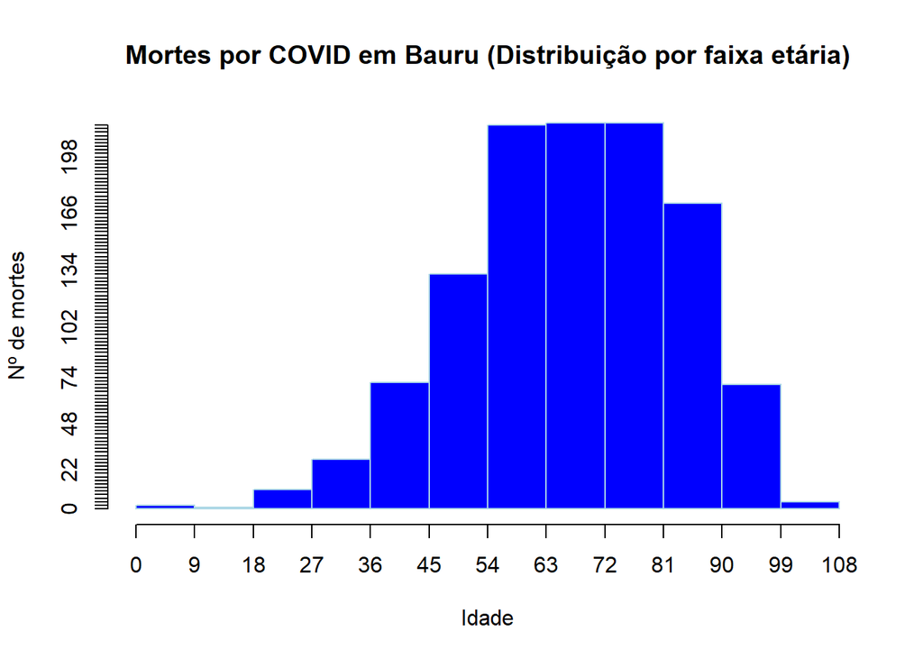

```r
k <- nclass.Sturges(dataset_casosbauru_mortes$idade)
AT <- max(dataset_casosbauru_mortes$idade[complete.cases(dataset_casosbauru_mortes$idade)]) - min(dataset_casosbauru_mortes$idade[complete.cases(dataset_casosbauru_mortes$idade)])
h <- ceiling(AT/k)
infclass <- min(dataset_casosbauru_mortes$idade[complete.cases(dataset_casosbauru_mortes$idade)])
supclass <- infclass + (k * h)
brk <- seq(infclass,supclass,h)

frequencia <- table(cut(dataset_casosbauru_mortes$idade[complete.cases(dataset_casosbauru_mortes$idade)], breaks = brk, right = FALSE))


hist(dataset_casosbauru_mortes$idade[complete.cases(dataset_casosbauru_mortes$idade)],
     main = "Mortes por COVID em Bauru (Distribuição por faixa etária)",
     xlab = "Idade", ylab = "Nº de mortes",
     col = c("blue"),
     border = c("lightblue"),
     breaks = brk,
     right = FALSE,
     axes = FALSE
     )
axis(1, at=seq(infclass,supclass,h))
axis(2, at=seq(0,max(frequencia),2))
```

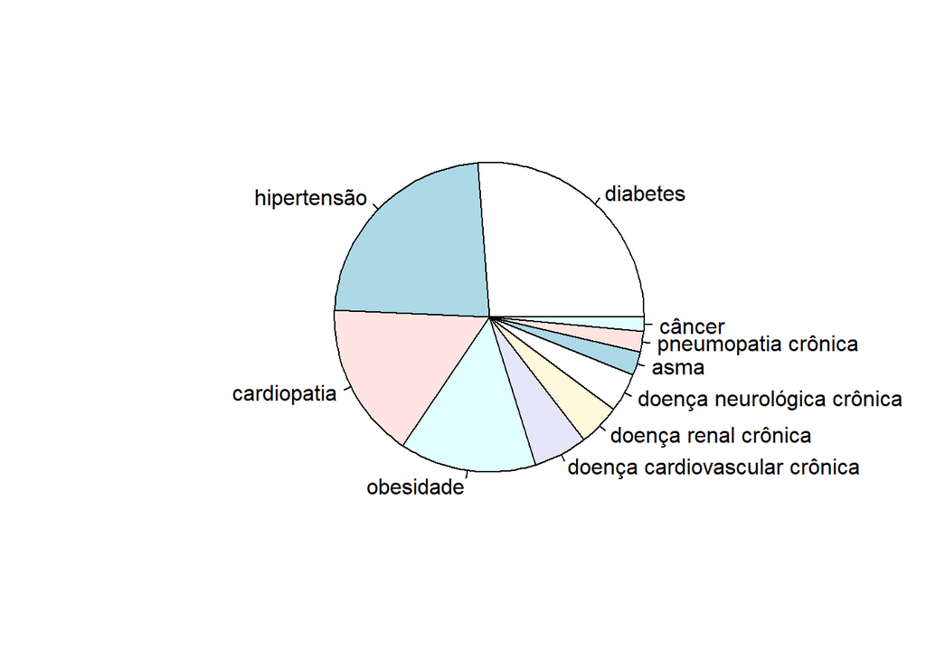

```r
x <- c(dataset_casosbauru_mortes$comorbidade[complete.cases(dataset_casosbauru_mortes$comorbidade)])
t <- strsplit(x," e ")
d <- unlist(t)
tabela <- as.data.frame(table(d))
tabela <- tabela[with(tabela,order(-Freq)),]
tabela <- tabela[1:10,]
pie(tabela$Freq, labels = tabela$d)
```

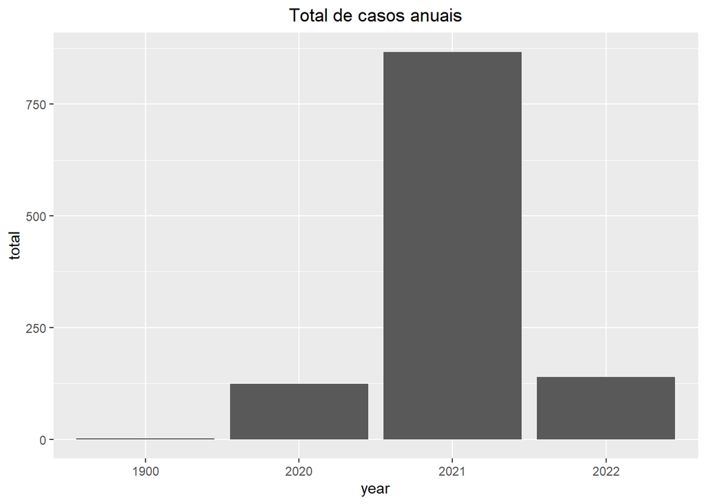

```r
data_morte <- as.Date(dataset_casosbauru_mortes$data_obito[complete.cases(dataset_casosbauru_mortes$data_obito)], format = "%d/%m/%Y")
df <- as.data.frame(table(data_morte))
df$data_morte <- as.Date(df$data_morte)
df_ano <- df %>% mutate(year = format(data_morte, "%Y")) %>%
  group_by(year) %>% summarise(total = sum(Freq))
df_anos <- df %>% mutate(month = format(data_morte, "%m"), year = format(data_morte, "%Y")) %>%
  group_by(month,year) %>% summarise(total = sum(Freq))
df_2020 <- filter(df_anos, year == 2020)
df_2021 <- filter(df_anos, year == 2021)
df_2022 <- filter(df_anos, year == 2022)
df_geral <- c(df_2020,df_2021,df_2022)

ggplot(data = df_ano) +
  geom_col(aes(y = total, x = year)) +
  ggtitle(paste("Total de casos anuais")) +
  theme(plot.title = element_text(hjust = 0.5))
```

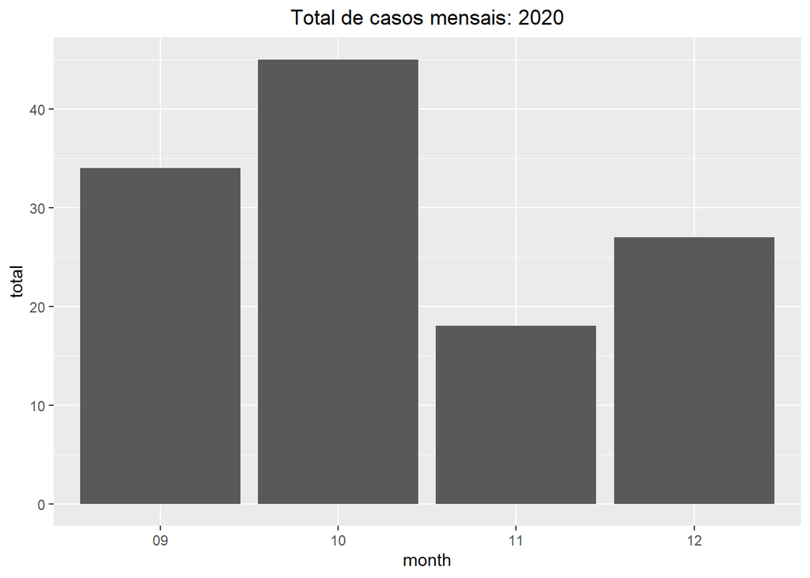

```r
ggplot(data = df_2020) +
  geom_col(aes(y = total, x = month)) +
  ggtitle(paste("Total de casos mensais: 2020")) +
  theme(plot.title = element_text(hjust = 0.5))
```

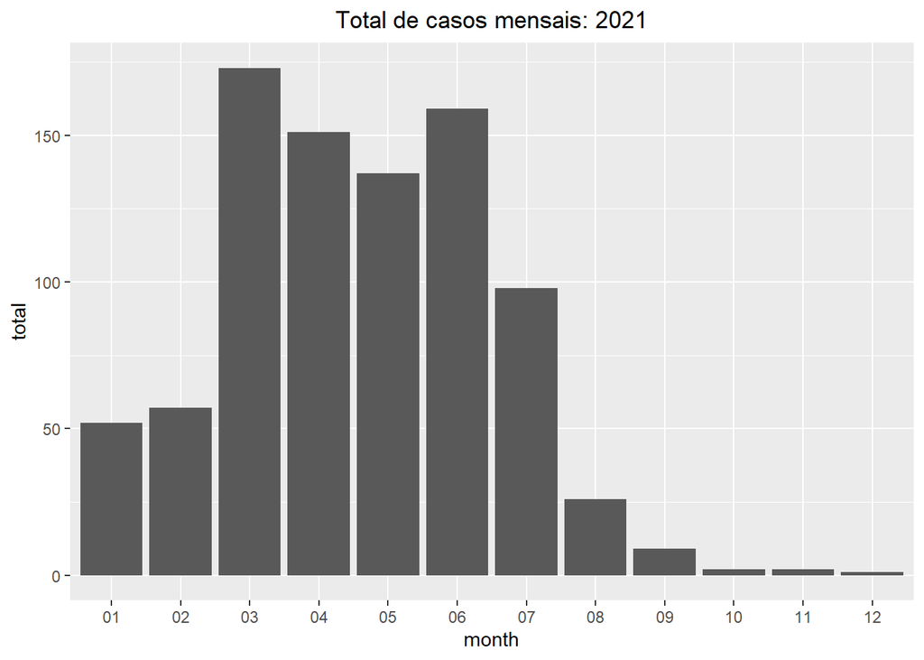

```r
ggplot(data = df_2021) +
  geom_col(aes(y = total, x = month)) +
  ggtitle(paste("Total de casos mensais: 2021")) +
  theme(plot.title = element_text(hjust = 0.5))
```

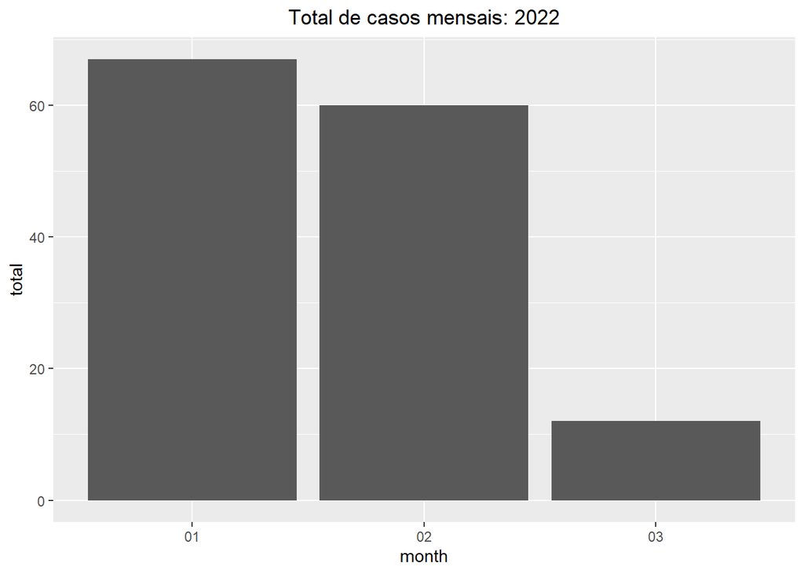

```r
ggplot(data = df_2022) +
  geom_col(aes(y = total, x = month)) +
  ggtitle(paste("Total de casos mensais: 2022")) +
  theme(plot.title = element_text(hjust = 0.5))
```